# Risk Factor Analysis

## Outcome Variable

**Outcome Variable:** haz

## Predictor Variables

**Intervention Variable:** predexfd6

**Adjustment Set:**

- arm
- sex
- brthmon
- W_mage
- meducyrs
- feducyrs
- hhwealth_quart
- hfoodsec
- W_mhtcm
- W_mwtkg
- W_mbmi
- vagbrth
- W_gagebrth
- W_birthwt
- W_birthlen
- W_nrooms
- W_nchldlt5
- month
- W_parity
- impfloor
- impsan
- safeh20
- delta_W_mage
- delta_meducyrs
- delta_feducyrs
- delta_hhwealth_quart
- delta_hfoodsec
- delta_W_mhtcm
- delta_W_mwtkg
- delta_W_mbmi
- delta_vagbrth
- delta_W_gagebrth
- delta_W_birthwt
- delta_W_birthlen
- delta_W_nrooms
- delta_W_nchldlt5
- delta_month
- delta_W_parity
- delta_impfloor
- delta_impsan
- delta_safeh20

## Stratifying Variables

The analysis was stratified on these variable(s):

- agecat
- studyid
- country

## Data Summary

| agecat | studyid | country | predexfd6 | n_cell | n |
| --- | --- | --- | --- | --- | --- |
| Birth | ki0047075b-MAL-ED | BANGLADESH | 1 | 72 | 205 |
| Birth | ki0047075b-MAL-ED | BANGLADESH | 0 | 133 | 205 |
| Birth | ki0047075b-MAL-ED | BRAZIL | 1 | 6 | 60 |
| Birth | ki0047075b-MAL-ED | BRAZIL | 0 | 54 | 60 |
| Birth | ki0047075b-MAL-ED | INDIA | 1 | 4 | 39 |
| Birth | ki0047075b-MAL-ED | INDIA | 0 | 35 | 39 |
| Birth | ki0047075b-MAL-ED | NEPAL | 1 | 3 | 24 |
| Birth | ki0047075b-MAL-ED | NEPAL | 0 | 21 | 24 |
| Birth | ki0047075b-MAL-ED | PERU | 1 | 73 | 213 |
| Birth | ki0047075b-MAL-ED | PERU | 0 | 140 | 213 |
| Birth | ki0047075b-MAL-ED | SOUTH AFRICA | 1 | 1 | 91 |
| Birth | ki0047075b-MAL-ED | SOUTH AFRICA | 0 | 90 | 91 |
| Birth | ki0047075b-MAL-ED | TANZANIA, UNITED REPUBLIC OF | 1 | 0 | 113 |
| Birth | ki0047075b-MAL-ED | TANZANIA, UNITED REPUBLIC OF | 0 | 113 | 113 |
| Birth | ki1000108-CMC-V-BCS-2002 | INDIA | 1 | 7 | 7 |
| Birth | ki1000108-CMC-V-BCS-2002 | INDIA | 0 | 0 | 7 |
| Birth | ki1000108-IRC | INDIA | 1 | 0 | 14 |
| Birth | ki1000108-IRC | INDIA | 0 | 14 | 14 |
| Birth | ki1000109-EE | PAKISTAN | 1 | 38 | 42 |
| Birth | ki1000109-EE | PAKISTAN | 0 | 4 | 42 |
| Birth | ki1000304b-SAS-CompFeed | INDIA | 1 | 346 | 364 |
| Birth | ki1000304b-SAS-CompFeed | INDIA | 0 | 18 | 364 |
| Birth | ki1017093b-PROVIDE | BANGLADESH | 1 | 159 | 539 |
| Birth | ki1017093b-PROVIDE | BANGLADESH | 0 | 380 | 539 |
| Birth | ki1101329-Keneba | GAMBIA | 1 | 6 | 12 |
| Birth | ki1101329-Keneba | GAMBIA | 0 | 6 | 12 |
| Birth | ki1113344-GMS-Nepal | NEPAL | 1 | 419 | 563 |
| Birth | ki1113344-GMS-Nepal | NEPAL | 0 | 144 | 563 |
| Birth | kiGH5241-JiVitA-3 | BANGLADESH | 1 | 12323 | 15793 |
| Birth | kiGH5241-JiVitA-3 | BANGLADESH | 0 | 3470 | 15793 |

[output cut: 70 more lines]

The following strata were considered:

- agecat: 24 months, studyid: ki0047075b-MAL-ED, country: BANGLADESH
- agecat: 24 months, studyid: ki0047075b-MAL-ED, country: BRAZIL
- agecat: 24 months, studyid: ki0047075b-MAL-ED, country: INDIA
- agecat: 24 months, studyid: ki0047075b-MAL-ED, country: NEPAL
- agecat: 24 months, studyid: ki0047075b-MAL-ED, country: PERU
- agecat: 24 months, studyid: ki0047075b-MAL-ED, country: SOUTH AFRICA
- agecat: 24 months, studyid: ki0047075b-MAL-ED, country: TANZANIA, UNITED REPUBLIC OF
- agecat: 24 months, studyid: ki1000108-CMC-V-BCS-2002, country: INDIA
- agecat: 24 months, studyid: ki1000108-IRC, country: INDIA
- agecat: 24 months, studyid: ki1000109-EE, country: PAKISTAN
- agecat: 24 months, studyid: ki1017093b-PROVIDE, country: BANGLADESH
- agecat: 24 months, studyid: ki1101329-Keneba, country: GAMBIA
- agecat: 24 months, studyid: ki1113344-GMS-Nepal, country: NEPAL
- agecat: 24 months, studyid: ki1148112-LCNI-5, country: MALAWI
- agecat: 24 months, studyid: kiGH5241-JiVitA-3, country: BANGLADESH
- agecat: 24 months, studyid: kiGH5241-JiVitA-4, country: BANGLADESH
- agecat: 6 months, studyid: ki0047075b-MAL-ED, country: BANGLADESH
- agecat: 6 months, studyid: ki0047075b-MAL-ED, country: BRAZIL
- agecat: 6 months, studyid: ki0047075b-MAL-ED, country: INDIA
- agecat: 6 months, studyid: ki0047075b-MAL-ED, country: NEPAL
- agecat: 6 months, studyid: ki0047075b-MAL-ED, country: PERU
- agecat: 6 months, studyid: ki0047075b-MAL-ED, country: SOUTH AFRICA
- agecat: 6 months, studyid: ki0047075b-MAL-ED, country: TANZANIA, UNITED REPUBLIC OF
- agecat: 6 months, studyid: ki1000108-CMC-V-BCS-2002, country: INDIA
- agecat: 6 months, studyid: ki1000108-IRC, country: INDIA
- agecat: 6 months, studyid: ki1000109-EE, country: PAKISTAN
- agecat: 6 months, studyid: ki1000304b-SAS-CompFeed, country: INDIA
- agecat: 6 months, studyid: ki1000304b-SAS-FoodSuppl, country: INDIA
- agecat: 6 months, studyid: ki1017093b-PROVIDE, country: BANGLADESH
- agecat: 6 months, studyid: ki1101329-Keneba, country: GAMBIA
- agecat: 6 months, studyid: ki1113344-GMS-Nepal, country: NEPAL
- agecat: 6 months, studyid: ki1148112-LCNI-5, country: MALAWI
- agecat: 6 months, studyid: kiGH5241-JiVitA-3, country: BANGLADESH
- agecat: 6 months, studyid: kiGH5241-JiVitA-4, country: BANGLADESH
- agecat: Birth, studyid: ki0047075b-MAL-ED, country: BANGLADESH
- agecat: Birth, studyid: ki0047075b-MAL-ED, country: BRAZIL
- agecat: Birth, studyid: ki0047075b-MAL-ED, country: INDIA
- agecat: Birth, studyid: ki0047075b-MAL-ED, country: NEPAL
- agecat: Birth, studyid: ki0047075b-MAL-ED, country: PERU
- agecat: Birth, studyid: ki0047075b-MAL-ED, country: SOUTH AFRICA
- agecat: Birth, studyid: ki0047075b-MAL-ED, country: TANZANIA, UNITED REPUBLIC OF
- agecat: Birth, studyid: ki1000108-CMC-V-BCS-2002, country: INDIA
- agecat: Birth, studyid: ki1000108-IRC, country: INDIA
- agecat: Birth, studyid: ki1000109-EE, country: PAKISTAN
- agecat: Birth, studyid: ki1000304b-SAS-CompFeed, country: INDIA
- agecat: Birth, studyid: ki1017093b-PROVIDE, country: BANGLADESH
- agecat: Birth, studyid: ki1101329-Keneba, country: GAMBIA
- agecat: Birth, studyid: ki1113344-GMS-Nepal, country: NEPAL
- agecat: Birth, studyid: kiGH5241-JiVitA-3, country: BANGLADESH
- agecat: Birth, studyid: kiGH5241-JiVitA-4, country: BANGLADESH

### Dropped Strata

Some strata were dropped due to rare outcomes:

- agecat: Birth, studyid: ki0047075b-MAL-ED, country: INDIA
- agecat: Birth, studyid: ki0047075b-MAL-ED, country: NEPAL
- agecat: Birth, studyid: ki0047075b-MAL-ED, country: SOUTH AFRICA
- agecat: Birth, studyid: ki0047075b-MAL-ED, country: TANZANIA, UNITED REPUBLIC OF
- agecat: Birth, studyid: ki1000108-CMC-V-BCS-2002, country: INDIA
- agecat: Birth, studyid: ki1000108-IRC, country: INDIA
- agecat: Birth, studyid: ki1000109-EE, country: PAKISTAN
- agecat: 6 months, studyid: ki0047075b-MAL-ED, country: SOUTH AFRICA
- agecat: 6 months, studyid: ki0047075b-MAL-ED, country: TANZANIA, UNITED REPUBLIC OF
- agecat: 6 months, studyid: ki1000108-CMC-V-BCS-2002, country: INDIA
- agecat: 6 months, studyid: ki1000108-IRC, country: INDIA
- agecat: 6 months, studyid: ki1000304b-SAS-FoodSuppl, country: INDIA
- agecat: 24 months, studyid: ki0047075b-MAL-ED, country: SOUTH AFRICA
- agecat: 24 months, studyid: ki0047075b-MAL-ED, country: TANZANIA, UNITED REPUBLIC OF
- agecat: 24 months, studyid: ki1000108-CMC-V-BCS-2002, country: INDIA
- agecat: 24 months, studyid: ki1000108-IRC, country: INDIA
- agecat: 24 months, studyid: ki1000109-EE, country: PAKISTAN

## Methods Detail

We’re interested in the causal parameters $E[Y_a]$ for all values of $a \in \mathcal{A}$. These parameters represent the mean outcome if, possibly contrary to fact, we intervened to set all units to have $A=a$. Under the randomization and positivity assumptions, these are identified by the statistical parameters $\psi_a=E_W[E_{Y|A,W}(Y|A=a,W)]$. In addition, we’re interested in the mean of $Y$, $E[Y]$ under no intervention (the observed mean). We will estimate these parameters by using SuperLearner to fit the relevant likelihood factors – $E_{Y|A,W}(Y|A=a,W)$ and $p(A=a|W)$, and then updating our likelihood fit using a joint TMLE.

For unadjusted analyses ($W=\{\}$), initial likelihoods were estimated using Lrnr_glm to estimate the simple $E(Y|A)$ and Lrnr_mean to estimate $p(A)$. For adjusted analyses, a small library containing Lrnr_glmnet, Lrnr_xgboost, and Lrnr_mean was used.

Having estimated these parameters, we will then use the delta method to estimate relative risks and attributable risks relative to a prespecified baseline level of $A$.

# Results Detail

## Results Plots

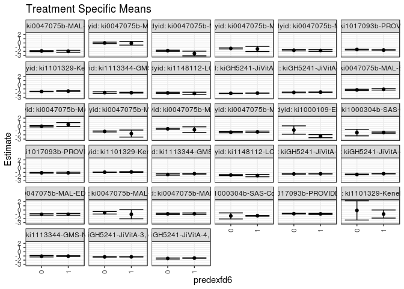

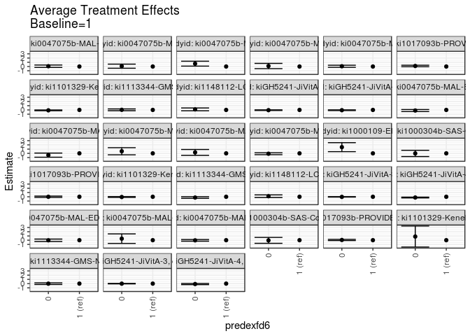

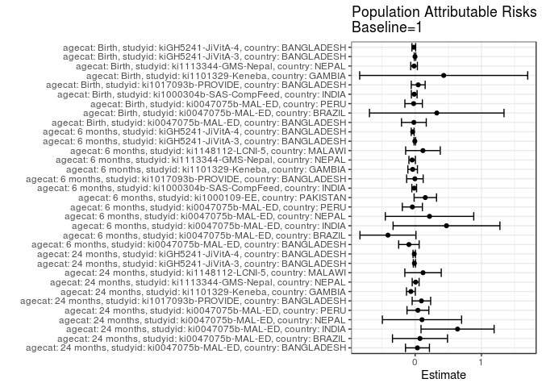

## Results Table

### Parameter: TSM

| agecat | studyid | country | intervention_level | baseline_level | estimate | ci_lower | ci_upper |
| --- | --- | --- | --- | --- | --- | --- | --- |
| Birth | ki0047075b-MAL-ED | BANGLADESH | 1 | NA | -1.0332810 | -1.2551204 | -0.8114416 |
| Birth | ki0047075b-MAL-ED | BANGLADESH | 0 | NA | -1.0568171 | -1.2346097 | -0.8790245 |
| Birth | ki0047075b-MAL-ED | BRAZIL | 1 | NA | -1.0216667 | -2.1085384 | 0.0652051 |
| Birth | ki0047075b-MAL-ED | BRAZIL | 0 | NA | -0.6601852 | -0.9595686 | -0.3608018 |
| Birth | ki0047075b-MAL-ED | PERU | 1 | NA | -0.8829307 | -1.0519576 | -0.7139039 |
| Birth | ki0047075b-MAL-ED | PERU | 0 | NA | -0.9179744 | -1.0642687 | -0.7716801 |
| Birth | ki1000304b-SAS-CompFeed | INDIA | 1 | NA | -1.3791683 | -1.4632120 | -1.2951246 |
| Birth | ki1000304b-SAS-CompFeed | INDIA | 0 | NA | -1.4196640 | -2.1447080 | -0.6946200 |
| Birth | ki1017093b-PROVIDE | BANGLADESH | 1 | NA | -0.9305003 | -1.0581823 | -0.8028182 |
| Birth | ki1017093b-PROVIDE | BANGLADESH | 0 | NA | -0.8770089 | -0.9628203 | -0.7911975 |
| Birth | ki1101329-Keneba | GAMBIA | 1 | NA | -0.9616667 | -1.9274750 | 0.0041417 |
| Birth | ki1101329-Keneba | GAMBIA | 0 | NA | -0.1016667 | -2.3897981 | 2.1864648 |
| Birth | ki1113344-GMS-Nepal | NEPAL | 1 | NA | -1.0470387 | -1.1443193 | -0.9497582 |
| Birth | ki1113344-GMS-Nepal | NEPAL | 0 | NA | -1.0567689 | -1.2341070 | -0.8794308 |
| Birth | kiGH5241-JiVitA-3 | BANGLADESH | 1 | NA | -1.2127747 | -1.2466718 | -1.1788777 |
| Birth | kiGH5241-JiVitA-3 | BANGLADESH | 0 | NA | -1.2249042 | -1.2785567 | -1.1712517 |
| Birth | kiGH5241-JiVitA-4 | BANGLADESH | 1 | NA | -1.5062781 | -1.5583799 | -1.4541762 |
| Birth | kiGH5241-JiVitA-4 | BANGLADESH | 0 | NA | -1.6062035 | -1.7359419 | -1.4764652 |
| 6 months | ki0047075b-MAL-ED | BANGLADESH | 1 | NA | -1.0956591 | -1.2791473 | -0.9121708 |
| 6 months | ki0047075b-MAL-ED | BANGLADESH | 0 | NA | -1.2383311 | -1.3957464 | -1.0809158 |
| 6 months | ki0047075b-MAL-ED | BRAZIL | 1 | NA | 0.4617123 | 0.0014314 | 0.9219932 |
| 6 months | ki0047075b-MAL-ED | BRAZIL | 0 | NA | 0.0426046 | -0.1082354 | 0.1934446 |
| 6 months | ki0047075b-MAL-ED | INDIA | 1 | NA | -1.6911595 | -2.5294903 | -0.8528287 |
| 6 months | ki0047075b-MAL-ED | INDIA | 0 | NA | -1.1936085 | -1.3149904 | -1.0722266 |
| 6 months | ki0047075b-MAL-ED | NEPAL | 1 | NA | -0.7781050 | -1.4624953 | -0.0937147 |
| 6 months | ki0047075b-MAL-ED | NEPAL | 0 | NA | -0.5555850 | -0.6740154 | -0.4371545 |
| 6 months | ki0047075b-MAL-ED | PERU | 1 | NA | -1.2837600 | -1.4635649 | -1.1039551 |
| 6 months | ki0047075b-MAL-ED | PERU | 0 | NA | -1.3711371 | -1.5077575 | -1.2345166 |
| 6 months | ki1000109-EE | PAKISTAN | 1 | NA | -2.3121318 | -2.6865239 | -1.9377397 |
| 6 months | ki1000109-EE | PAKISTAN | 0 | NA | -0.8473333 | -1.8424880 | 0.1478213 |
| 6 months | ki1000304b-SAS-CompFeed | INDIA | 1 | NA | -1.4549959 | -1.6008850 | -1.3091069 |
| 6 months | ki1000304b-SAS-CompFeed | INDIA | 0 | NA | -1.4654856 | -2.2428805 | -0.6880907 |
| 6 months | ki1017093b-PROVIDE | BANGLADESH | 1 | NA | -1.0873010 | -1.2237113 | -0.9508908 |
| 6 months | ki1017093b-PROVIDE | BANGLADESH | 0 | NA | -1.0911908 | -1.1792705 | -1.0031111 |
| 6 months | ki1101329-Keneba | GAMBIA | 1 | NA | -0.8947098 | -0.9821941 | -0.8072255 |
| 6 months | ki1101329-Keneba | GAMBIA | 0 | NA | -0.9485621 | -1.0071543 | -0.8899699 |
| 6 months | ki1113344-GMS-Nepal | NEPAL | 1 | NA | -1.3083556 | -1.3970364 | -1.2196748 |
| 6 months | ki1113344-GMS-Nepal | NEPAL | 0 | NA | -1.4910831 | -1.6592993 | -1.3228669 |
| 6 months | ki1148112-LCNI-5 | MALAWI | 1 | NA | -1.7566429 | -2.0406186 | -1.4726672 |
| 6 months | ki1148112-LCNI-5 | MALAWI | 0 | NA | -1.6249598 | -1.7565797 | -1.4933398 |
| 6 months | kiGH5241-JiVitA-3 | BANGLADESH | 1 | NA | -1.3313965 | -1.3618436 | -1.3009494 |
| 6 months | kiGH5241-JiVitA-3 | BANGLADESH | 0 | NA | -1.3564077 | -1.4057757 | -1.3070398 |
| 6 months | kiGH5241-JiVitA-4 | BANGLADESH | 1 | NA | -1.3100239 | -1.3510716 | -1.2689761 |
| 6 months | kiGH5241-JiVitA-4 | BANGLADESH | 0 | NA | -1.4845127 | -1.5743809 | -1.3946444 |
| 24 months | ki0047075b-MAL-ED | BANGLADESH | 1 | NA | -1.9924562 | -2.2334667 | -1.7514457 |
| 24 months | ki0047075b-MAL-ED | BANGLADESH | 0 | NA | -1.9220502 | -2.0684826 | -1.7756178 |
| 24 months | ki0047075b-MAL-ED | BRAZIL | 1 | NA | -0.0651969 | -0.5115434 | 0.3811497 |
| 24 months | ki0047075b-MAL-ED | BRAZIL | 0 | NA | 0.0155274 | -0.1681018 | 0.1991566 |
| 24 months | ki0047075b-MAL-ED | INDIA | 1 | NA | -2.5240426 | -3.0878941 | -1.9601912 |
| 24 months | ki0047075b-MAL-ED | INDIA | 0 | NA | -1.8492357 | -1.9807269 | -1.7177445 |
| 24 months | ki0047075b-MAL-ED | NEPAL | 1 | NA | -1.4259227 | -2.0386625 | -0.8131830 |
| 24 months | ki0047075b-MAL-ED | NEPAL | 0 | NA | -1.3087319 | -1.4345111 | -1.1829528 |
| 24 months | ki0047075b-MAL-ED | PERU | 1 | NA | -1.7953554 | -1.9980140 | -1.5926968 |
| 24 months | ki0047075b-MAL-ED | PERU | 0 | NA | -1.7347706 | -1.8840403 | -1.5855009 |
| 24 months | ki1017093b-PROVIDE | BANGLADESH | 1 | NA | -1.6961691 | -1.8542123 | -1.5381260 |
| 24 months | ki1017093b-PROVIDE | BANGLADESH | 0 | NA | -1.5684340 | -1.6645882 | -1.4722799 |
| 24 months | ki1101329-Keneba | GAMBIA | 1 | NA | -1.5230278 | -1.6052429 | -1.4408127 |
| 24 months | ki1101329-Keneba | GAMBIA | 0 | NA | -1.6182137 | -1.6833013 | -1.5531262 |
| 24 months | ki1113344-GMS-Nepal | NEPAL | 1 | NA | -1.9070585 | -2.0024010 | -1.8117160 |
| 24 months | ki1113344-GMS-Nepal | NEPAL | 0 | NA | -1.8824770 | -2.0756258 | -1.6893282 |
| 24 months | ki1148112-LCNI-5 | MALAWI | 1 | NA | -2.0834343 | -2.3761184 | -1.7907502 |
| 24 months | ki1148112-LCNI-5 | MALAWI | 0 | NA | -1.9565064 | -2.1152729 | -1.7977398 |
| 24 months | kiGH5241-JiVitA-3 | BANGLADESH | 1 | NA | -2.0055363 | -2.0453285 | -1.9657441 |
| 24 months | kiGH5241-JiVitA-3 | BANGLADESH | 0 | NA | -2.0593161 | -2.1267443 | -1.9918879 |
| 24 months | kiGH5241-JiVitA-4 | BANGLADESH | 1 | NA | -1.7770286 | -1.8189977 | -1.7350595 |
| 24 months | kiGH5241-JiVitA-4 | BANGLADESH | 0 | NA | -1.8402006 | -1.9190956 | -1.7613057 |

### Parameter: E(Y)

| agecat | studyid | country | intervention_level | baseline_level | estimate | ci_lower | ci_upper |
| --- | --- | --- | --- | --- | --- | --- | --- |
| Birth | ki0047075b-MAL-ED | BANGLADESH | NA | NA | -1.0530244 | -1.1913751 | -0.9146736 |
| Birth | ki0047075b-MAL-ED | BRAZIL | NA | NA | -0.6963333 | -0.9881882 | -0.4044785 |
| Birth | ki0047075b-MAL-ED | PERU | NA | NA | -0.9065728 | -1.0297267 | -0.7834188 |
| Birth | ki1000304b-SAS-CompFeed | INDIA | NA | NA | -1.3937088 | -1.5095039 | -1.2779137 |
| Birth | ki1017093b-PROVIDE | BANGLADESH | NA | NA | -0.8851020 | -0.9601332 | -0.8100709 |
| Birth | ki1101329-Keneba | GAMBIA | NA | NA | -0.5316667 | -1.7992053 | 0.7358720 |
| Birth | ki1113344-GMS-Nepal | NEPAL | NA | NA | -1.0641208 | -1.1525364 | -0.9757052 |
| Birth | kiGH5241-JiVitA-3 | BANGLADESH | NA | NA | -1.2156259 | -1.2478377 | -1.1834141 |
| Birth | kiGH5241-JiVitA-4 | BANGLADESH | NA | NA | -1.5273138 | -1.5765339 | -1.4780937 |
| 6 months | ki0047075b-MAL-ED | BANGLADESH | NA | NA | -1.1905988 | -1.3103463 | -1.0708514 |
| 6 months | ki0047075b-MAL-ED | BRAZIL | NA | NA | 0.0510207 | -0.0930194 | 0.1950608 |
| 6 months | ki0047075b-MAL-ED | INDIA | NA | NA | -1.2185703 | -1.3422027 | -1.0949380 |
| 6 months | ki0047075b-MAL-ED | NEPAL | NA | NA | -0.5616889 | -0.6770008 | -0.4463770 |
| 6 months | ki0047075b-MAL-ED | PERU | NA | NA | -1.3264945 | -1.4355111 | -1.2174779 |
| 6 months | ki1000109-EE | PAKISTAN | NA | NA | -2.1595486 | -2.5331781 | -1.7859192 |
| 6 months | ki1000304b-SAS-CompFeed | INDIA | NA | NA | -1.4697236 | -1.6333919 | -1.3060553 |
| 6 months | ki1017093b-PROVIDE | BANGLADESH | NA | NA | -1.0916915 | -1.1661176 | -1.0172654 |
| 6 months | ki1101329-Keneba | GAMBIA | NA | NA | -0.9331108 | -0.9823173 | -0.8839043 |
| 6 months | ki1113344-GMS-Nepal | NEPAL | NA | NA | -1.3540280 | -1.4334801 | -1.2745760 |
| 6 months | ki1148112-LCNI-5 | MALAWI | NA | NA | -1.6395956 | -1.7592633 | -1.5199278 |
| 6 months | kiGH5241-JiVitA-3 | BANGLADESH | NA | NA | -1.3370052 | -1.3650190 | -1.3089913 |
| 6 months | kiGH5241-JiVitA-4 | BANGLADESH | NA | NA | -1.3482303 | -1.3866421 | -1.3098185 |
| 24 months | ki0047075b-MAL-ED | BANGLADESH | NA | NA | -1.9581707 | -2.0862906 | -1.8300508 |
| 24 months | ki0047075b-MAL-ED | BRAZIL | NA | NA | 0.0071006 | -0.1615817 | 0.1757828 |
| 24 months | ki0047075b-MAL-ED | INDIA | NA | NA | -1.8848804 | -2.0154334 | -1.7543274 |
| 24 months | ki0047075b-MAL-ED | NEPAL | NA | NA | -1.3232192 | -1.4452887 | -1.2011496 |
| 24 months | ki0047075b-MAL-ED | PERU | NA | NA | -1.7544776 | -1.8753255 | -1.6336298 |
| 24 months | ki1017093b-PROVIDE | BANGLADESH | NA | NA | -1.6024221 | -1.6857420 | -1.5191023 |
| 24 months | ki1101329-Keneba | GAMBIA | NA | NA | -1.5876293 | -1.6406755 | -1.5345831 |
| 24 months | ki1113344-GMS-Nepal | NEPAL | NA | NA | -1.9002128 | -1.9869255 | -1.8135001 |
| 24 months | ki1148112-LCNI-5 | MALAWI | NA | NA | -1.9651323 | -2.1053230 | -1.8249415 |
| 24 months | kiGH5241-JiVitA-3 | BANGLADESH | NA | NA | -2.0173019 | -2.0536076 | -1.9809962 |
| 24 months | kiGH5241-JiVitA-4 | BANGLADESH | NA | NA | -1.7914765 | -1.8297816 | -1.7531715 |

### Parameter: ATE

| agecat | studyid | country | intervention_level | baseline_level | estimate | ci_lower | ci_upper |
| --- | --- | --- | --- | --- | --- | --- | --- |
| Birth | ki0047075b-MAL-ED | BANGLADESH | 1 | 1 | 0.0000000 | 0.0000000 | 0.0000000 |
| Birth | ki0047075b-MAL-ED | BANGLADESH | 0 | 1 | -0.0235361 | -0.3087823 | 0.2617101 |
| Birth | ki0047075b-MAL-ED | BRAZIL | 1 | 1 | 0.0000000 | 0.0000000 | 0.0000000 |
| Birth | ki0047075b-MAL-ED | BRAZIL | 0 | 1 | 0.3614815 | -0.7658697 | 1.4888326 |
| Birth | ki0047075b-MAL-ED | PERU | 1 | 1 | 0.0000000 | 0.0000000 | 0.0000000 |
| Birth | ki0047075b-MAL-ED | PERU | 0 | 1 | -0.0350437 | -0.2311734 | 0.1610860 |
| Birth | ki1000304b-SAS-CompFeed | INDIA | 1 | 1 | 0.0000000 | 0.0000000 | 0.0000000 |
| Birth | ki1000304b-SAS-CompFeed | INDIA | 0 | 1 | -0.0404957 | -0.7393477 | 0.6583563 |
| Birth | ki1017093b-PROVIDE | BANGLADESH | 1 | 1 | 0.0000000 | 0.0000000 | 0.0000000 |
| Birth | ki1017093b-PROVIDE | BANGLADESH | 0 | 1 | 0.0534914 | -0.0854572 | 0.1924400 |
| Birth | ki1101329-Keneba | GAMBIA | 1 | 1 | 0.0000000 | 0.0000000 | 0.0000000 |
| Birth | ki1101329-Keneba | GAMBIA | 0 | 1 | 0.8600000 | -1.6236126 | 3.3436126 |
| Birth | ki1113344-GMS-Nepal | NEPAL | 1 | 1 | 0.0000000 | 0.0000000 | 0.0000000 |
| Birth | ki1113344-GMS-Nepal | NEPAL | 0 | 1 | -0.0097302 | -0.2052287 | 0.1857684 |
| Birth | kiGH5241-JiVitA-3 | BANGLADESH | 1 | 1 | 0.0000000 | 0.0000000 | 0.0000000 |
| Birth | kiGH5241-JiVitA-3 | BANGLADESH | 0 | 1 | -0.0121295 | -0.0656867 | 0.0414278 |
| Birth | kiGH5241-JiVitA-4 | BANGLADESH | 1 | 1 | 0.0000000 | 0.0000000 | 0.0000000 |
| Birth | kiGH5241-JiVitA-4 | BANGLADESH | 0 | 1 | -0.0999255 | -0.2386931 | 0.0388421 |
| 6 months | ki0047075b-MAL-ED | BANGLADESH | 1 | 1 | 0.0000000 | 0.0000000 | 0.0000000 |
| 6 months | ki0047075b-MAL-ED | BANGLADESH | 0 | 1 | -0.1426721 | -0.3851219 | 0.0997777 |
| 6 months | ki0047075b-MAL-ED | BRAZIL | 1 | 1 | 0.0000000 | 0.0000000 | 0.0000000 |
| 6 months | ki0047075b-MAL-ED | BRAZIL | 0 | 1 | -0.4191078 | -0.9062301 | 0.0680146 |
| 6 months | ki0047075b-MAL-ED | INDIA | 1 | 1 | 0.0000000 | 0.0000000 | 0.0000000 |
| 6 months | ki0047075b-MAL-ED | INDIA | 0 | 1 | 0.4975510 | -0.3495003 | 1.3446023 |
| 6 months | ki0047075b-MAL-ED | NEPAL | 1 | 1 | 0.0000000 | 0.0000000 | 0.0000000 |
| 6 months | ki0047075b-MAL-ED | NEPAL | 0 | 1 | 0.2225200 | -0.4719359 | 0.9169759 |
| 6 months | ki0047075b-MAL-ED | PERU | 1 | 1 | 0.0000000 | 0.0000000 | 0.0000000 |
| 6 months | ki0047075b-MAL-ED | PERU | 0 | 1 | -0.0873771 | -0.3143378 | 0.1395837 |
| 6 months | ki1000109-EE | PAKISTAN | 1 | 1 | 0.0000000 | 0.0000000 | 0.0000000 |
| 6 months | ki1000109-EE | PAKISTAN | 0 | 1 | 1.4647984 | 0.4015477 | 2.5280492 |
| 6 months | ki1000304b-SAS-CompFeed | INDIA | 1 | 1 | 0.0000000 | 0.0000000 | 0.0000000 |
| 6 months | ki1000304b-SAS-CompFeed | INDIA | 0 | 1 | -0.0104897 | -0.7471588 | 0.7261794 |
| 6 months | ki1017093b-PROVIDE | BANGLADESH | 1 | 1 | 0.0000000 | 0.0000000 | 0.0000000 |
| 6 months | ki1017093b-PROVIDE | BANGLADESH | 0 | 1 | -0.0038898 | -0.1663248 | 0.1585453 |
| 6 months | ki1101329-Keneba | GAMBIA | 1 | 1 | 0.0000000 | 0.0000000 | 0.0000000 |
| 6 months | ki1101329-Keneba | GAMBIA | 0 | 1 | -0.0538523 | -0.1575847 | 0.0498801 |
| 6 months | ki1113344-GMS-Nepal | NEPAL | 1 | 1 | 0.0000000 | 0.0000000 | 0.0000000 |
| 6 months | ki1113344-GMS-Nepal | NEPAL | 0 | 1 | -0.1827275 | -0.3718737 | 0.0064187 |
| 6 months | ki1148112-LCNI-5 | MALAWI | 1 | 1 | 0.0000000 | 0.0000000 | 0.0000000 |
| 6 months | ki1148112-LCNI-5 | MALAWI | 0 | 1 | 0.1316832 | -0.1814224 | 0.4447888 |
| 6 months | kiGH5241-JiVitA-3 | BANGLADESH | 1 | 1 | 0.0000000 | 0.0000000 | 0.0000000 |
| 6 months | kiGH5241-JiVitA-3 | BANGLADESH | 0 | 1 | -0.0250112 | -0.0775980 | 0.0275755 |
| 6 months | kiGH5241-JiVitA-4 | BANGLADESH | 1 | 1 | 0.0000000 | 0.0000000 | 0.0000000 |
| 6 months | kiGH5241-JiVitA-4 | BANGLADESH | 0 | 1 | -0.1744888 | -0.2717254 | -0.0772522 |
| 24 months | ki0047075b-MAL-ED | BANGLADESH | 1 | 1 | 0.0000000 | 0.0000000 | 0.0000000 |
| 24 months | ki0047075b-MAL-ED | BANGLADESH | 0 | 1 | 0.0704060 | -0.2112239 | 0.3520359 |
| 24 months | ki0047075b-MAL-ED | BRAZIL | 1 | 1 | 0.0000000 | 0.0000000 | 0.0000000 |
| 24 months | ki0047075b-MAL-ED | BRAZIL | 0 | 1 | 0.0807243 | -0.4031417 | 0.5645904 |
| 24 months | ki0047075b-MAL-ED | INDIA | 1 | 1 | 0.0000000 | 0.0000000 | 0.0000000 |
| 24 months | ki0047075b-MAL-ED | INDIA | 0 | 1 | 0.6748070 | 0.0953070 | 1.2543069 |
| 24 months | ki0047075b-MAL-ED | NEPAL | 1 | 1 | 0.0000000 | 0.0000000 | 0.0000000 |
| 24 months | ki0047075b-MAL-ED | NEPAL | 0 | 1 | 0.1171908 | -0.5076506 | 0.7420322 |
| 24 months | ki0047075b-MAL-ED | PERU | 1 | 1 | 0.0000000 | 0.0000000 | 0.0000000 |
| 24 months | ki0047075b-MAL-ED | PERU | 0 | 1 | 0.0605848 | -0.1869830 | 0.3081526 |
| 24 months | ki1017093b-PROVIDE | BANGLADESH | 1 | 1 | 0.0000000 | 0.0000000 | 0.0000000 |
| 24 months | ki1017093b-PROVIDE | BANGLADESH | 0 | 1 | 0.1277351 | -0.0551221 | 0.3105923 |
| 24 months | ki1101329-Keneba | GAMBIA | 1 | 1 | 0.0000000 | 0.0000000 | 0.0000000 |
| 24 months | ki1101329-Keneba | GAMBIA | 0 | 1 | -0.0951859 | -0.1961294 | 0.0057576 |
| 24 months | ki1113344-GMS-Nepal | NEPAL | 1 | 1 | 0.0000000 | 0.0000000 | 0.0000000 |
| 24 months | ki1113344-GMS-Nepal | NEPAL | 0 | 1 | 0.0245815 | -0.1894251 | 0.2385880 |
| 24 months | ki1148112-LCNI-5 | MALAWI | 1 | 1 | 0.0000000 | 0.0000000 | 0.0000000 |
| 24 months | ki1148112-LCNI-5 | MALAWI | 0 | 1 | 0.1269280 | -0.2065274 | 0.4603833 |
| 24 months | kiGH5241-JiVitA-3 | BANGLADESH | 1 | 1 | 0.0000000 | 0.0000000 | 0.0000000 |
| 24 months | kiGH5241-JiVitA-3 | BANGLADESH | 0 | 1 | -0.0537798 | -0.1268599 | 0.0193003 |
| 24 months | kiGH5241-JiVitA-4 | BANGLADESH | 1 | 1 | 0.0000000 | 0.0000000 | 0.0000000 |
| 24 months | kiGH5241-JiVitA-4 | BANGLADESH | 0 | 1 | -0.0631720 | -0.1482453 | 0.0219013 |

### Parameter: PAR

| agecat | studyid | country | intervention_level | baseline_level | estimate | ci_lower | ci_upper |
| --- | --- | --- | --- | --- | --- | --- | --- |
| Birth | ki0047075b-MAL-ED | BANGLADESH | 1 | NA | -0.0197434 | -0.2064178 | 0.1669311 |
| Birth | ki0047075b-MAL-ED | BRAZIL | 1 | NA | 0.3253333 | -0.6896600 | 1.3403266 |
| Birth | ki0047075b-MAL-ED | PERU | 1 | NA | -0.0236420 | -0.1554457 | 0.1081617 |
| Birth | ki1000304b-SAS-CompFeed | INDIA | 1 | NA | -0.0145405 | -0.0577897 | 0.0287087 |
| Birth | ki1017093b-PROVIDE | BANGLADESH | 1 | NA | 0.0453982 | -0.0595076 | 0.1503040 |
| Birth | ki1101329-Keneba | GAMBIA | 1 | NA | 0.4300000 | -0.8375387 | 1.6975387 |
| Birth | ki1113344-GMS-Nepal | NEPAL | 1 | NA | -0.0170820 | -0.0671716 | 0.0330075 |
| Birth | kiGH5241-JiVitA-3 | BANGLADESH | 1 | NA | -0.0028512 | -0.0146190 | 0.0089167 |
| Birth | kiGH5241-JiVitA-4 | BANGLADESH | 1 | NA | -0.0210358 | -0.0493251 | 0.0072536 |
| 6 months | ki0047075b-MAL-ED | BANGLADESH | 1 | NA | -0.0949398 | -0.2495003 | 0.0596207 |
| 6 months | ki0047075b-MAL-ED | BRAZIL | 1 | NA | -0.4106916 | -0.8331727 | 0.0117895 |
| 6 months | ki0047075b-MAL-ED | INDIA | 1 | NA | 0.4725892 | -0.3332025 | 1.2783809 |
| 6 months | ki0047075b-MAL-ED | NEPAL | 1 | NA | 0.2164161 | -0.4508933 | 0.8837255 |
| 6 months | ki0047075b-MAL-ED | PERU | 1 | NA | -0.0427345 | -0.1941239 | 0.1086550 |
| 6 months | ki1000109-EE | PAKISTAN | 1 | NA | 0.1525832 | -0.0166253 | 0.3217916 |
| 6 months | ki1000304b-SAS-CompFeed | INDIA | 1 | NA | -0.0147277 | -0.0507565 | 0.0213012 |
| 6 months | ki1017093b-PROVIDE | BANGLADESH | 1 | NA | -0.0043905 | -0.1290615 | 0.1202805 |
| 6 months | ki1101329-Keneba | GAMBIA | 1 | NA | -0.0384010 | -0.1105171 | 0.0337152 |
| 6 months | ki1113344-GMS-Nepal | NEPAL | 1 | NA | -0.0456724 | -0.0945763 | 0.0032315 |
| 6 months | ki1148112-LCNI-5 | MALAWI | 1 | NA | 0.1170473 | -0.1441540 | 0.3782487 |
| 6 months | kiGH5241-JiVitA-3 | BANGLADESH | 1 | NA | -0.0056087 | -0.0175948 | 0.0063775 |
| 6 months | kiGH5241-JiVitA-4 | BANGLADESH | 1 | NA | -0.0382065 | -0.0597333 | -0.0166796 |
| 24 months | ki0047075b-MAL-ED | BANGLADESH | 1 | NA | 0.0342855 | -0.1463998 | 0.2149707 |
| 24 months | ki0047075b-MAL-ED | BRAZIL | 1 | NA | 0.0722975 | -0.3428325 | 0.4874275 |
| 24 months | ki0047075b-MAL-ED | INDIA | 1 | NA | 0.6391623 | 0.0877988 | 1.1905257 |
| 24 months | ki0047075b-MAL-ED | NEPAL | 1 | NA | 0.1027035 | -0.4950258 | 0.7004329 |
| 24 months | ki0047075b-MAL-ED | PERU | 1 | NA | 0.0408778 | -0.1238817 | 0.2056373 |
| 24 months | ki1017093b-PROVIDE | BANGLADESH | 1 | NA | 0.0937470 | -0.0459146 | 0.2334086 |
| 24 months | ki1101329-Keneba | GAMBIA | 1 | NA | -0.0646015 | -0.1314541 | 0.0022511 |
| 24 months | ki1113344-GMS-Nepal | NEPAL | 1 | NA | 0.0068457 | -0.0450868 | 0.0587782 |
| 24 months | ki1148112-LCNI-5 | MALAWI | 1 | NA | 0.1183021 | -0.1565057 | 0.3931099 |
| 24 months | kiGH5241-JiVitA-3 | BANGLADESH | 1 | NA | -0.0117656 | -0.0284238 | 0.0048925 |
| 24 months | kiGH5241-JiVitA-4 | BANGLADESH | 1 | NA | -0.0144479 | -0.0324163 | 0.0035205 |